# rpc

[figure not shown]

**REGISTRO E PROTEÇÃO DE CULTIVARES**

Prof. Saulo Chaves

ESALQ / USP - Departamento de Genética

LGN 313 - Melhoramento Genético

## Anteriormente em LGN0313

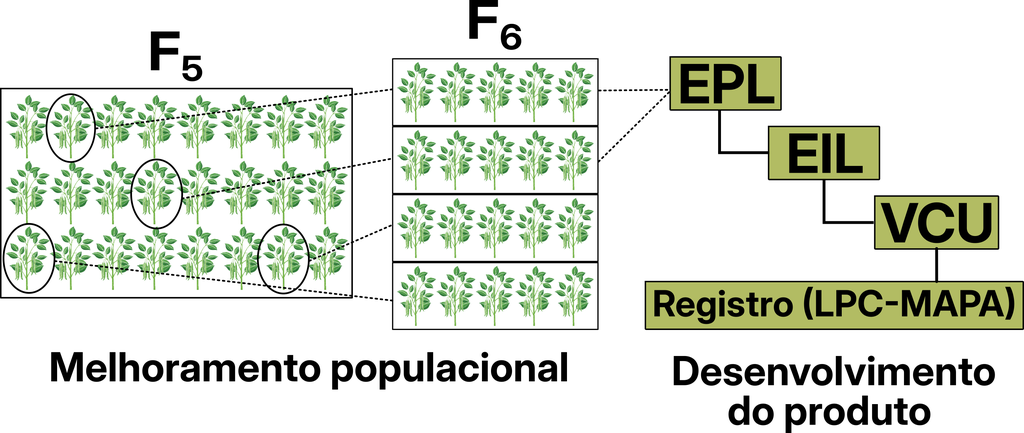

## Anteriormente em LGN0313

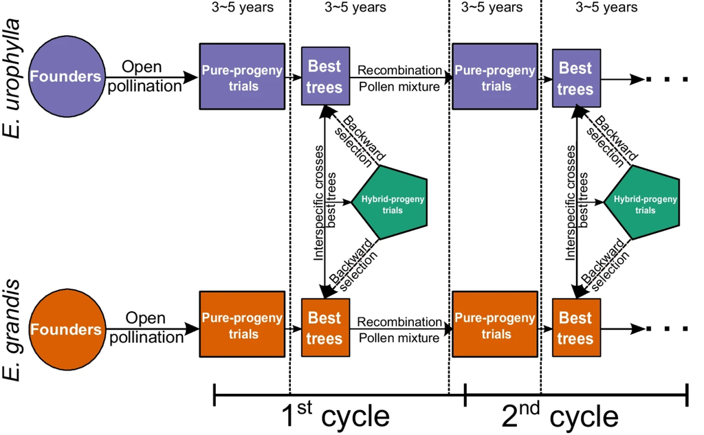

## Anteriormente em LGN0313

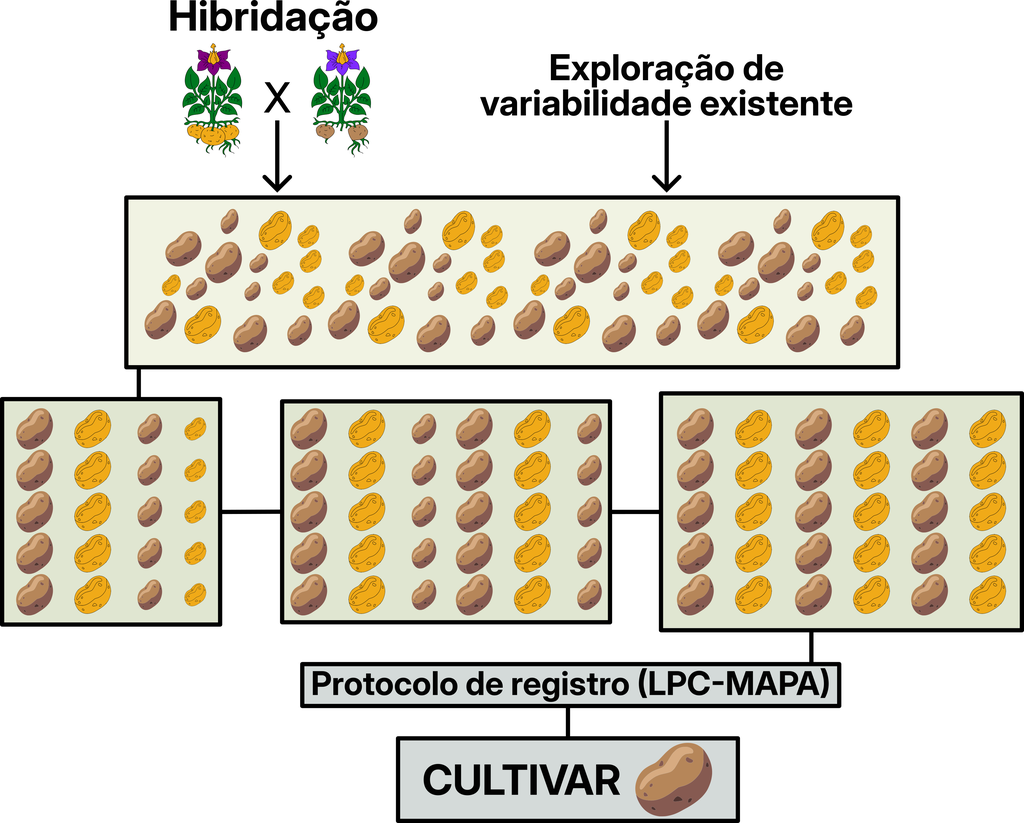

## Conteúdo de hoje

1. Contexto
   - Internacional
   - Nacional
2. Lei de Proteção de Cultivares
   - Proteção de cultivares
   - Registro de cultivares

# Contexto

## Quanto custa gerar uma cultivar?

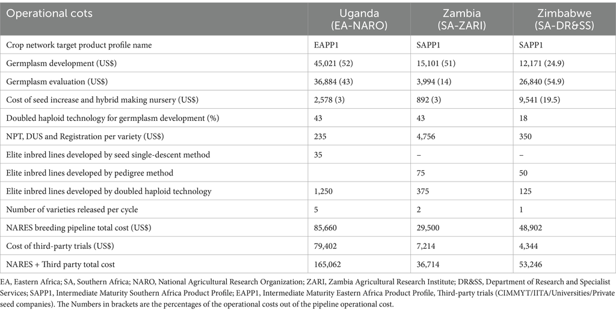

[Das et al. (2025)](https://www.frontiersin.org/journals/sustainable-food-systems/articles/10.3389/fsufs.2025.1545600/full)

## Quanto custa gerar uma cultivar?

- Por que é importante gerar novas cultivares?

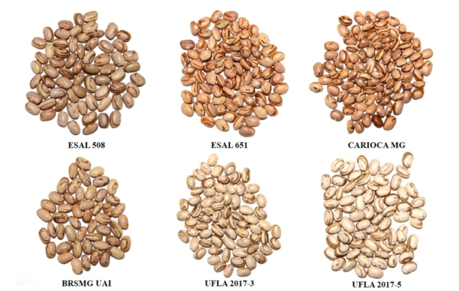

[Página Rural](https://www.paginarural.com.br/noticia/273391/ha-50-anos-pesquisas-da-ufla-colaboram-para-melhorar-a-qualidade-do-feijao-carioca)

## Propriedade intelectual

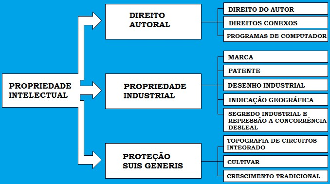

[Carlos Eduardo Vanin](https://www.jusbrasil.com.br/artigos/propriedade-intelectual-conceito-evolucao-historica-e-normativa-e-sua-importancia/407435408)

## Propriedade intelectual

- Sistema que resguarda os direitos do desenvolvedor da tecnologia
  - Desenvolvedor: melhorista
  - Tecnologia: cultivar

**Cultivar**

*“A variedade de qualquer gênero ou espécie vegetal superior que seja claramente distinguível de outras cultivares conhecidas por margem mínima de descritores, por sua denominação própria, que seja homogênea e estável quanto aos descritores através de gerações sucessivas e seja de espécie passível de uso pelo complexo agroflorestal, descrita em publicação especializada disponível e acessível ao público, bem como a linhagem componente de híbridos”*

## Contexto mundial

- Marco (em nível mundial): criação da **UPOV**
  - *International Union for the Protection of New Varieties of Plants*
  - 1961 (com revisões em 1972, 1978 e 1991)

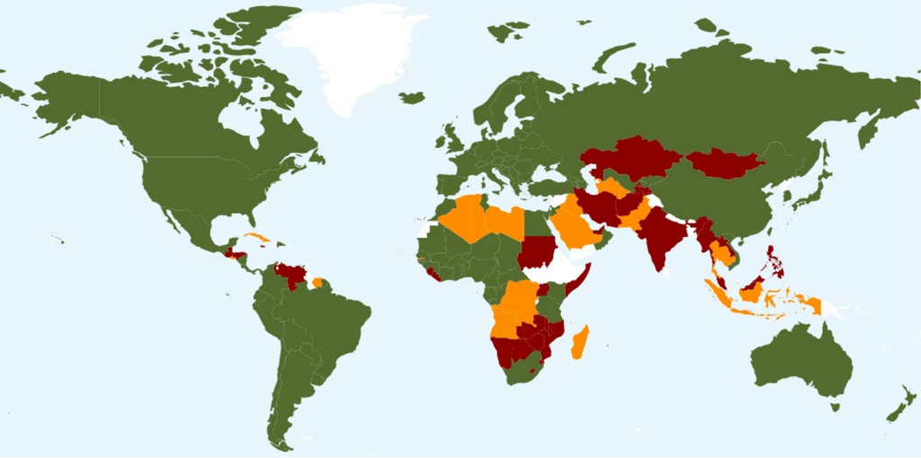

[UPOV (2025)](https://www.upov.int/edocs/pubdocs/en/upov_pub_437.pdf)

## Contexto mundial

- UPOV: ligada à Organização Mundial de Propriedade Intelectual
  - Reconhecida pela ONU
- Missão: *prover e promover um sistema eficiente de proteção de cultivares, visando encorajar o desenvolvimento de novas cultivares para benefício da sociedade*
- Dá base para o trânsito de cultivares entre países
  - Comercial
  - Pesquisa
- A Lei de Proteção de Cultivares do Brasil foi baseada nas convenções da UPOV

## Contexto mundial

**Sob o guarda-chuva da UPOV**:

A proteção só é **garantida** para cultivares:

- Novas
- Distintas
- Uniformes
- Estáveis

A proteção **não se aplica** para:

- Usos não-comerciais
- Usos privados
- Usos experimentais
- Desenvolvimento de novas variedades

## Contexto nacional

> “A proteção da propriedade industrial se efetua mediante […] a concessão de privilégio de patentes de invenção, modelos de utilidade desenhos ou modelos industriais, variedades novas de plantas.”

> — Código da Propriedade Industrial: decreto-lei Nº 7.903 de 27 de agosto de 1945
- Primeiras discussões sobre regulamentação *sui generis* em 1976
- Discussões retomadas em 1991
  - Liderada pelo Conselho Nacional de Política Agrícola
  - Participação de instituições interessadas
- Reformulação da Lei das Patentes: material específico para o melhoramento vegetal

## Contexto nacional

> “Não se considera invenção nem modelo de utilidade […] o todo ou parte de seres vivos naturais e materiais biológicos encontrados na natureza, ou ainda que dela isolados, inclusive o genoma ou germoplasma de qualquer ser vivo natural e os processos biológicos naturais.”

> — Lei das Patentes: Lei Nº 9.279, de 14 de maio de 1996

## Contexto nacional

> “Não são patenteáveis […] o todo ou parte dos seres vivos, exceto os microorganismos **transgênicos** que atendam aos três requisitos de patenteabilidade - novidade, atividade inventiva e aplicação industrial - previstos no art. 8º e que não sejam mera descoberta. […] Para os fins desta Lei, microorganismos transgênicos são organismos, exceto o todo ou parte de plantas ou de animais, que expressem, mediante intervenção humana direta em sua composição genética, uma característica normalmente não alcançável pela espécie em condições naturais.”

> — Lei das Patentes: Lei Nº 9.279, de 14 de maio de 1996

## Contexto nacional

- Lei nº 9.456, de 25 de abril de 1997 (Lei de Proteção de Cultivares - LPC)
- Decreto nº 2.366, de 5 de novembro de 1997 (Decreto regulamentador da LPC)
- Decreto nº 3.109, de 30 de junho de 1999 (Decreto presidencial que promulgou a Convenção Internacional para a Proteção das Obtenções Vegetais)
- Lei nº 10.711, de 05 de agosto de 2003 (Lei de Sementes e Mudas)

# Lei de Proteção de Cultivares

## Lei de Proteção de Cultivares

- Garante a **proteção intelectual** do processo de obtenção da cultivar
  - Protege o direito dos obtentores
  - Estimula novas iniciativas de desenvolvimento de cultivares
- Reconhece o processo laborioso do melhoramento
- Sistema *sui generis* de proteção de cultivares

## Lei de Proteção de Cultivares

- É passível de proteção a nova cultivar ou cultivar essencialmente derivada, de qualquer gênero ou espécie vegetal
- A proteção da cultivar recairá sobre o material de reprodução ou de multiplicação vegetativa da planta inteira

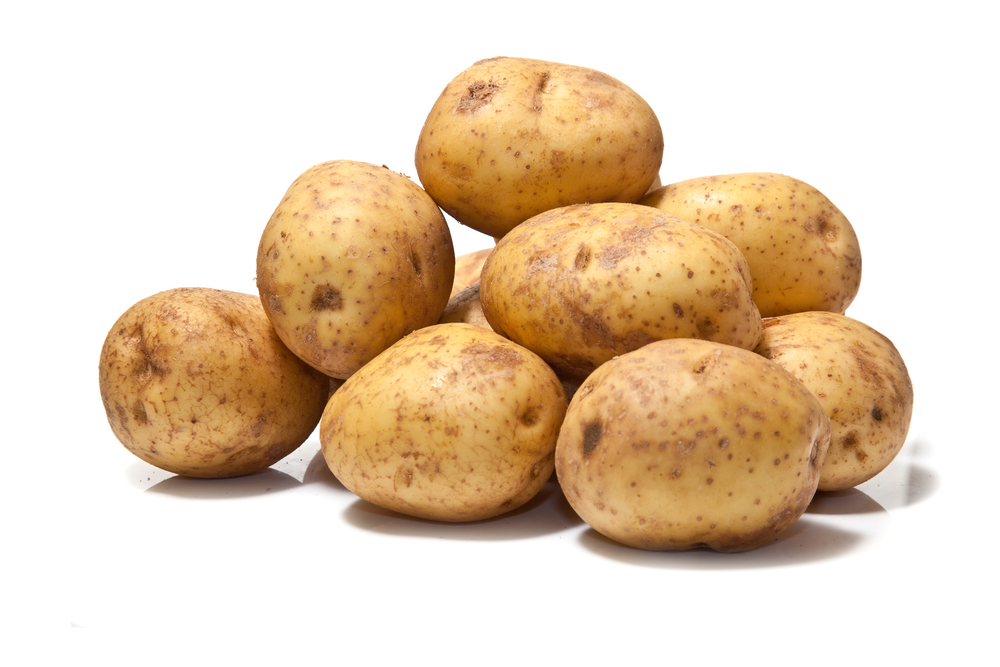

[Edward Westmacott](https://www.collinsdictionary.com/pt/dictionary/english/potato)

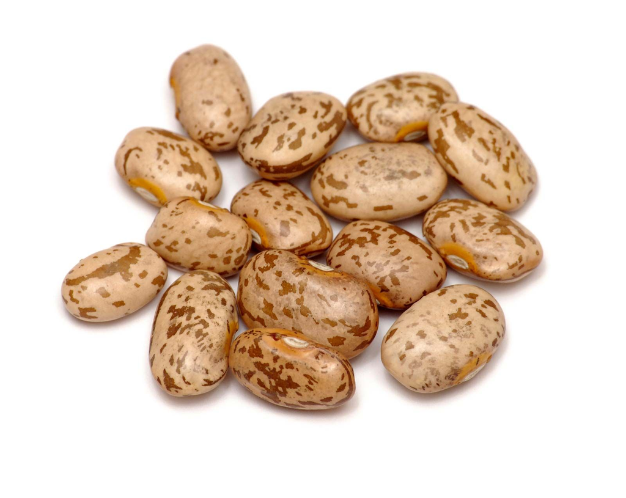

[Britannica](https://www.britannica.com/plant/common-bean)

## Lei de Proteção de Cultivares

- [Serviço Nacional de Proteção de Cultivares (SNPC)](https://sistemas.agricultura.gov.br/snpc/cultivarweb/cultivares_protegidas.php)
  - Tramitação da requisição de proteção
  - Outorga de certificação
  - Divulgação das cultivares e seus descritores mínimos
  - Criação de normas para conservação e diferenciação da cultivar

## Lei de Proteção de Cultivares

- Obtentores: melhoristas e instituições
  - Para cultivares internacionais, é necessário representante legal no Brasil
- A proteção assegura o direito à reprodução comercial no território brasileiro
- [Proteção $\neq$ registro](https://sistemas.agricultura.gov.br/snpc/cultivarweb/index.php)
- É vedado a terceiros (sem devida autorização):
  - Produção para fins comerciais
  - Oferecimento à venda ou comercialização do material propagativo

## Lei de Proteção de Cultivares

Não estará ferindo a lei quem:

- Reserva e planta sementes para uso próprio
- Usa ou vende como alimento ou matéria-prima o produto obtido do seu plantio, exceto para fins reprodutivos
- Utiliza a cultivar como fonte de variação no melhoramento genético ou na pesquisa científica
- Sendo *pequeno produtor rural ou agricultor familiar*, multiplica sementes, para doação ou troca, exclusivamente para outros pequenos produtores rurais

## Lei de Proteção de Cultivares

- O que acontece se eu usar uma cultivar comercial para desenvolver a minha?

> “Se for indispensável a utilização repetida da cultivar protegida para produção comercial de outra cultivar ou de híbrido, fica o titular da segunda obrigado a obter a autorização do titular do direito de proteção da primeira”

## Lei de Proteção de Cultivares

- O que acontece se eu usar uma cultivar comercial para desenvolver a minha?

> “Caso uma cultivar venha a ser caracterizada como essencialmente derivada de uma cultivar protegida, sua exploração comercial estará condicionada à autorização do titular da proteção desta mesma cultivar protegida”

## Lei de Proteção de Cultivares

Prazo de proteção:

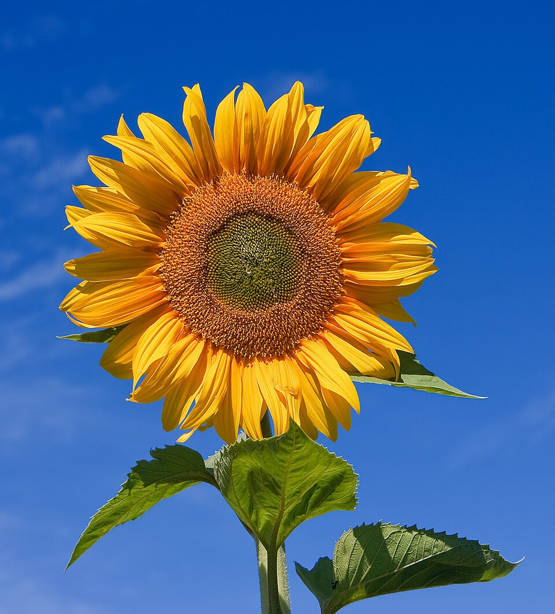

[Wikipedia](https://en.wikipedia.org/wiki/Common_sunflower)

15 anos (anuais)

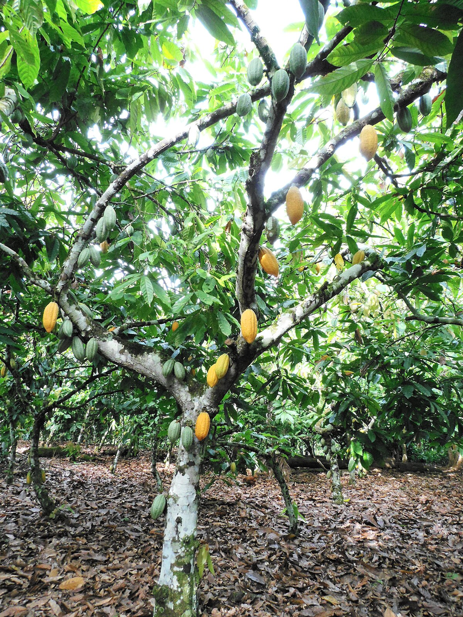

[Wikipedia](https://pt.wikipedia.org/wiki/Cacau)

18 anos (perenes)

- Após este período: domínio público

## Lei de Proteção de Cultivares

- Requisitos para proteção:
  - Ser produto de melhoramento genético
  - Ser de uma espécie passível de proteção no Brasil
  - Não ter sido oferecida à venda ou comercialização no exterior há mais de 4 ou 6 anos, para espécies anuais e perenes, respectivamente
  - Possuir denominação apropriada
  - Possuir amostra viva disponível a ser entregue ao SNPC

## Lei de Proteção de Cultivares

- Requisitos para proteção:
  - Distinguibilidade: a cultivar deve ser distinta daquelas já encontradas no mercado
  - Homogeneidade: Deve possuir características homogêneas, trazidas pelos seus descritos mínimos
  - Estabilidade: As características devem possuir repetibilidade (manifestadas de forma semelhante em vários ambientes)
- Testes de DHE: fase final do programa de melhoramento
  - Instruções específicas para cada espécie

## Lei de Proteção de Cultivares

- Requerimento via Cultivar Web
- [Relatório técnico](https://docs.google.com/document/d/1xtVV611kSGSDtWP6TQqVRxotL7tAxoai/edit?usp=drive_link&ouid=113462302392592083319&rtpof=true&sd=true)
- [Instruções de DHE e descritores mínimos](https://docs.google.com/document/d/14x2rGc0filpVM3bZuyvk5FEY8VICuJDP/edit?usp=drive_link&ouid=113462302392592083319&rtpof=true&sd=true)

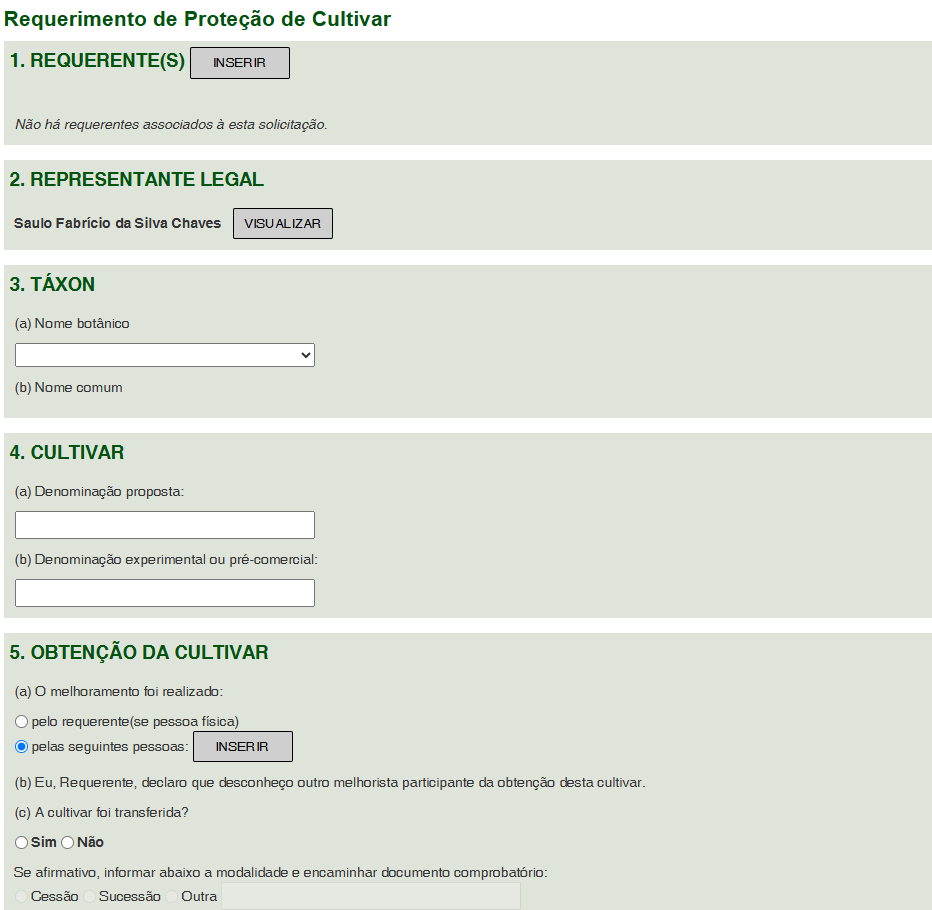

## Lei de Proteção de Cultivares

- Punições para transgressores:
  - Indenização ao obtentor da cultivar
  - Multa equivalente a 20% do valor comercial do material
  - Material apreendido (distribuido para agricultura familiar)
  - Duplicação da multa em caso de reincidência

## Registro de cultivares

- Proteção: concessão de um direito de propriedade intelectual
  - Exclusividade de exploração da cultivar protegida
- Registro: habilitar a cultivar para produção e comercialização
  - Lei Nº 10.711, de 5 de agosto de 2003 (Lei de Sementes e Mudas)
- Proteger o agricultor da venda indiscriminada de sementes e mudas de cultivares não testados
- Inscrição no [Registro Nacional de Cultivares](https://sistemas.agricultura.gov.br/snpc/cultivarweb/cultivares_registradas.php)

## Registro de cultivares

- Requisição pelo próprio obtentor ou o detentor dos direitos de proteção (procuração)
- O *mantenedor* deve dispor de material básico e assegurar as características da cultivar
- Determinação do Valor de Cultivo e Uso (VCU) da cultivar
  - Valor intrínseco de combinação das características agronômicas da cultivar e suas propriedades de uso
  - Fase final do programa de melhoramento
  - [Regras específicas](https://docs.google.com/document/d/1dLQuKRaUuLv-jJHqBaP9bDQ9lChITU7Q/edit?usp=drive_link&ouid=113462302392592083319&rtpof=true&sd=true) (a exemplo dos ensaios de DHE)
- Registro válido por 15 anos (prorrogáveis)

## Registro de cultivares

- Os VCUs são fiscalizados pelo MAPA
  - Deve-se [informar](https://docs.google.com/spreadsheets/d/1zju848x0KQG8AgnyupJK1c8Z4zaslCHr/edit?usp=drive_link&ouid=113462302392592083319&rtpof=true&sd=true) o local de instalação 30 dias antes
- Podem ser obtidos por terceiros, mas são de responsabilidade do mantenedor
- Atualmente, são exigidos dados de VCU para 29 espécies

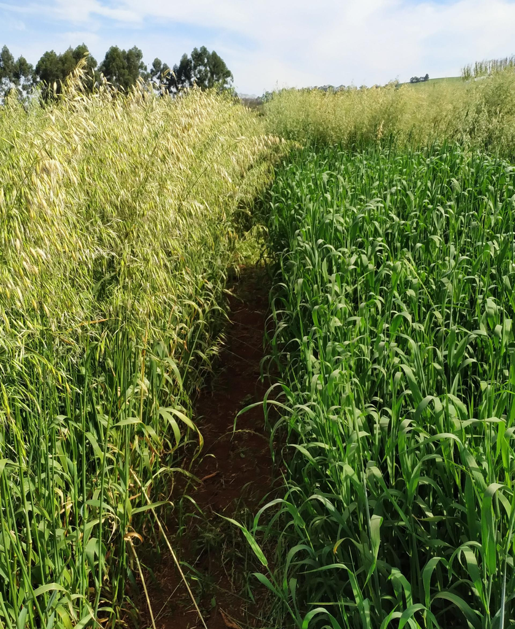

[Reprodução: UFSM](https://www.ufsm.br/2021/03/12/inovacao-para-o-campo-ufsm-obtem-protecao-de-novas-cultivares)

## Implicações da regulamentação

- Aumento da área plantada
- Maior interesse da iniciativa privada na indústria de sementes melhoradas
  - Importante na formação de novos melhoristas
- Fortalecimento institucional da pesquisa pública

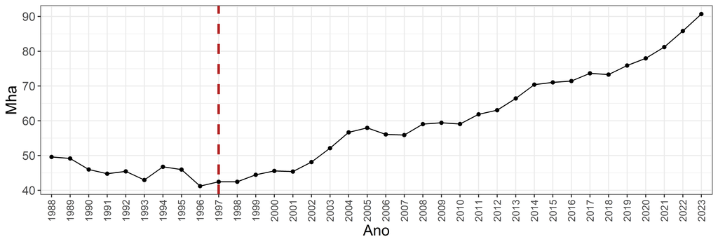

## Material de apoio

- [Lei de Proteção de Cultivares](https://www.planalto.gov.br/ccivil_03/leis/l9456.htm)
- [Lei de Sementes e Mudas](https://www.planalto.gov.br/ccivil_03/leis/2003/l10.711.htm)
- [Perguntas frequentes sobre a Lei de Proteção de Cultivares](https://www.gov.br/agricultura/pt-br/assuntos/insumos-agropecuarios/insumos-agricolas/protecao-de-cultivar/informacoes-publicacoes/2023_faq_snpc_30nov2023.pdf)
- [Propriedade Intelectual e Inovações na Agricultura - Capítulo 9: Proteção de cultivares e inovação](https://www.embrapa.br/busca-de-publicacoes/-/publicacao/1047036/propriedade-intelectual-e-inovacoes-na-agricultura)
- [A Lei de Proteção de Cultivares : análise de sua formulação e conteúdo](https://www.cdt.unb.br/images/CITT/Arquivos/documentos_CITT/Outros_documentos/lei_protecao_cultivares_araujo.pdf)

[figure not shown]

Grato!